# DA Final Project

## Library and Data Loading

```python
#Import libraries

import pandas as pd
import numpy as np
pd.options.display.max_columns = None
import seaborn as sns
import matplotlib.pyplot as plt

from scipy import stats

pd.options.display.max_columns = None

%matplotlib inline
sns.set()
sns.set(rc={'figure.figsize':(12, 8)})

import statsmodels.api as sm

#Load data
bike = pd.read_csv('SeoulBikeData.csv',encoding='ISO-8859-1')
```

## Data Preparation

```python
#Load data
bike = pd.read_csv('SeoulBikeData.csv',encoding='ISO-8859-1')

#Nonfunctioning days do not have a system to log rental activity. Drop all nonfunctioning day records.
indexNames = bike[bike['Functioning Day'] == 'No' ].index
bike.drop(indexNames , inplace=True)

#Transform Date column into Date type
bike['Date'] = bike['Date'].astype('datetime64[ns]')

#Rename Holiday to Holiday1

bike.rename(columns={'Holiday':'Holiday_'}, inplace=True)

#Get dummy variables
dummy_variable_1 = pd.get_dummies(bike["Seasons"])
bike = pd.concat([bike, dummy_variable_1], axis=1)

dummy_variable_2 = pd.get_dummies(bike["Holiday_"])
bike = pd.concat([bike, dummy_variable_2], axis=1)

dummy_variable_3 = pd.get_dummies(bike["Functioning Day"])
dummy_variable_3.rename(columns={'Yes':'Functioning Day', 'No':'Nonfunctioning Day'}, inplace=True)
bike = pd.concat([bike, dummy_variable_3], axis=1)

#Create columns for Month

bike['Month'] = bike['Date'].dt.month

#OneHot months

dummy_variable_4 = pd.get_dummies(bike["Month"])
dummy_variable_4.rename(columns={1:'January', 2:'February',3:'March',4:'April',5:'May',6:'June',7:'July',8:'August',9:'September',10:'October',11:'November',12:'December'}, inplace=True)
bike = pd.concat([bike, dummy_variable_4], axis=1)

#OneHot Hours
dummy_variable_5 = pd.get_dummies(bike["Hour"])
bike = pd.concat([bike, dummy_variable_5], axis=1)

#Add Weekday column
bike['Weekday'] = bike['Date'].dt.dayofweek

#Change names of the weekdays from numbers to actual names
conditions1 = [
    (bike['Weekday'] == 0),
    (bike['Weekday'] == 1) ,
    (bike['Weekday'] ==2) ,
    (bike['Weekday'] == 3) ,
    (bike['Weekday'] == 4),
    (bike['Weekday'] == 5),
    (bike['Weekday'] == 6)
    ]

## create a list of the values we want to assign for each condition
values1 = ['Sunday', 'Monday', 'Tuesday', 'Wednesday','Thursday','Friday','Saturday']

## create a new column and use np.select to assign values to it using our lists as arguments
bike['WeekDay'] = np.select(conditions1, values1)






####################
#Change names of the weekdays from numbers to actual names
conditions24 = [
    (bike['Hour'] <= 5),
    (bike['Hour'] > 5)  & (bike['Hour'] <= 10 )  ,
    (bike['Hour'] > 10) & (bike['Hour'] <= 15) ,
    (bike['Hour'] > 15) & (bike['Hour'] <= 22 ) ,
    (bike['Hour'] > 22)
    ]

## create a list of the values we want to assign for each condition
values24 = ['LateNight', 'Morning', 'Midday', 'Evening','LateNight']

## create a new column and use np.select to assign values to it using our lists as arguments
bike['TimeDay'] = np.select(conditions24, values24)






#Create a binary for variable for raining conditions. Is it raining? (yes/no)
conditions2 = [
    (bike['Rainfall(mm)'] == 0),
    (bike['Rainfall(mm)'] > 0)
        ]

## create a list of the values we want to assign for each condition
values2 = [0, 1]

## create a new column and use np.select to assign values to it using our lists as arguments
bike['Is_Raining'] = np.select(conditions2, values2)


#Create a binary for variable for snowing conditions. Is it snowing? (yes/no)
conditions3 = [
    (bike['Snowfall (cm)'] == 0),
    (bike['Snowfall (cm)'] > 0)
        ]

## create a list of the values we want to assign for each condition
values3 = [0, 1]

## create a new column and use np.select to assign values to it using our lists as arguments
bike['Is_Snowing'] = np.select(conditions3, values3)



bike.head()
```

|  | Date | Rented Bike Count | Hour | Temperature(°C) | Humidity(%) | Wind speed (m/s) | Visibility (10m) | Dew point temperature(°C) | Solar Radiation (MJ/m2) | Rainfall(mm) | Snowfall (cm) | Seasons | Holiday_ | Functioning Day | Autumn | Spring | Summer | Winter | Holiday | No Holiday | Functioning Day | Month | January | February | March | April | May | June | July | … |
| --- | --- | --- | --- | --- | --- | --- | --- | --- | --- | --- | --- | --- | --- | --- | --- | --- | --- | --- | --- | --- | --- | --- | --- | --- | --- | --- | --- | --- | --- | --- |
| 0 | 2017-01-12 | 254 | 0 | -5.2 | 37 | 2.2 | 2000 | -17.6 | 0.0 | 0.0 | 0.0 | Winter | No Holiday | Yes | 0 | 0 | 0 | 1 | 0 | 1 | 1 | 1 | 1 | 0 | 0 | 0 | 0 | 0 | 0 | … |
| 1 | 2017-01-12 | 204 | 1 | -5.5 | 38 | 0.8 | 2000 | -17.6 | 0.0 | 0.0 | 0.0 | Winter | No Holiday | Yes | 0 | 0 | 0 | 1 | 0 | 1 | 1 | 1 | 1 | 0 | 0 | 0 | 0 | 0 | 0 | … |
| 2 | 2017-01-12 | 173 | 2 | -6.0 | 39 | 1.0 | 2000 | -17.7 | 0.0 | 0.0 | 0.0 | Winter | No Holiday | Yes | 0 | 0 | 0 | 1 | 0 | 1 | 1 | 1 | 1 | 0 | 0 | 0 | 0 | 0 | 0 | … |
| 3 | 2017-01-12 | 107 | 3 | -6.2 | 40 | 0.9 | 2000 | -17.6 | 0.0 | 0.0 | 0.0 | Winter | No Holiday | Yes | 0 | 0 | 0 | 1 | 0 | 1 | 1 | 1 | 1 | 0 | 0 | 0 | 0 | 0 | 0 | … |
| 4 | 2017-01-12 | 78 | 4 | -6.0 | 36 | 2.3 | 2000 | -18.6 | 0.0 | 0.0 | 0.0 | Winter | No Holiday | Yes | 0 | 0 | 0 | 1 | 0 | 1 | 1 | 1 | 1 | 0 | 0 | 0 | 0 | 0 | 0 | … |

## Data Exploration (Type)

```python
bike.shape
```

```
(8465, 62)
```

```python
bike.describe()
```

|  | Rented Bike Count | Hour | Temperature(°C) | Humidity(%) | Wind speed (m/s) | Visibility (10m) | Dew point temperature(°C) | Solar Radiation (MJ/m2) | Rainfall(mm) | Snowfall (cm) | Autumn | Spring | Summer | Winter | Holiday | No Holiday | Functioning Day | Month | January | February | March | April | May | June | July | August | September | October | November | … |
| --- | --- | --- | --- | --- | --- | --- | --- | --- | --- | --- | --- | --- | --- | --- | --- | --- | --- | --- | --- | --- | --- | --- | --- | --- | --- | --- | --- | --- | --- | --- |
| count | 8465.000000 | 8465.000000 | 8465.000000 | 8465.000000 | 8465.000000 | 8465.000000 | 8465.000000 | 8465.000000 | 8465.00000 | 8465.000000 | 8465.000000 | 8465.000000 | 8465.000000 | 8465.000000 | 8465.000000 | 8465.000000 | 8465.0 | 8465.000000 | 8465.000000 | 8465.000000 | 8465.000000 | 8465.000000 | 8465.000000 | 8465.000000 | 8465.000000 | 8465.000000 | 8465.000000 | 8465.000000 | 8465.000000 | … |
| mean | 729.156999 | 11.507029 | 12.771057 | 58.147194 | 1.725883 | 1433.873479 | 3.944997 | 0.567868 | 0.14912 | 0.077685 | 0.228825 | 0.255168 | 0.260839 | 0.255168 | 0.048198 | 0.951802 | 1.0 | 6.493325 | 0.087891 | 0.076551 | 0.085056 | 0.082221 | 0.087891 | 0.081394 | 0.087891 | 0.087891 | 0.068045 | 0.085056 | 0.082221 | … |
| std | 642.351166 | 6.920899 | 12.104375 | 20.484839 | 1.034281 | 609.051229 | 13.242399 | 0.868245 | 1.12554 | 0.444063 | 0.420101 | 0.435982 | 0.439118 | 0.435982 | 0.214198 | 0.214198 | 0.0 | 3.463349 | 0.283154 | 0.265893 | 0.278982 | 0.274717 | 0.283154 | 0.273455 | 0.283154 | 0.283154 | 0.251838 | 0.278982 | 0.274717 | … |
| min | 2.000000 | 0.000000 | -17.800000 | 0.000000 | 0.000000 | 27.000000 | -30.600000 | 0.000000 | 0.00000 | 0.000000 | 0.000000 | 0.000000 | 0.000000 | 0.000000 | 0.000000 | 0.000000 | 1.0 | 1.000000 | 0.000000 | 0.000000 | 0.000000 | 0.000000 | 0.000000 | 0.000000 | 0.000000 | 0.000000 | 0.000000 | 0.000000 | 0.000000 | … |
| 25% | 214.000000 | 6.000000 | 3.000000 | 42.000000 | 0.900000 | 935.000000 | -5.100000 | 0.000000 | 0.00000 | 0.000000 | 0.000000 | 0.000000 | 0.000000 | 0.000000 | 0.000000 | 1.000000 | 1.0 | 4.000000 | 0.000000 | 0.000000 | 0.000000 | 0.000000 | 0.000000 | 0.000000 | 0.000000 | 0.000000 | 0.000000 | 0.000000 | 0.000000 | … |
| 50% | 542.000000 | 12.000000 | 13.500000 | 57.000000 | 1.500000 | 1690.000000 | 4.700000 | 0.010000 | 0.00000 | 0.000000 | 0.000000 | 0.000000 | 0.000000 | 0.000000 | 0.000000 | 1.000000 | 1.0 | 6.000000 | 0.000000 | 0.000000 | 0.000000 | 0.000000 | 0.000000 | 0.000000 | 0.000000 | 0.000000 | 0.000000 | 0.000000 | 0.000000 | … |
| 75% | 1084.000000 | 18.000000 | 22.700000 | 74.000000 | 2.300000 | 2000.000000 | 15.200000 | 0.930000 | 0.00000 | 0.000000 | 0.000000 | 1.000000 | 1.000000 | 1.000000 | 0.000000 | 1.000000 | 1.0 | 10.000000 | 0.000000 | 0.000000 | 0.000000 | 0.000000 | 0.000000 | 0.000000 | 0.000000 | 0.000000 | 0.000000 | 0.000000 | 0.000000 | … |
| max | 3556.000000 | 23.000000 | 39.400000 | 98.000000 | 7.400000 | 2000.000000 | 27.200000 | 3.520000 | 35.00000 | 8.800000 | 1.000000 | 1.000000 | 1.000000 | 1.000000 | 1.000000 | 1.000000 | 1.0 | 12.000000 | 1.000000 | 1.000000 | 1.000000 | 1.000000 | 1.000000 | 1.000000 | 1.000000 | 1.000000 | 1.000000 | 1.000000 | 1.000000 | … |

```python
bike.isnull().sum()
```

```
Date                 0
Rented Bike Count    0
Hour                 0
Temperature(°C)      0
Humidity(%)          0
                    ..
23                   0
Weekday              0
WeekDay              0
Is_Raining           0
Is_Snowing           0
Length: 62, dtype: int64
```

```python
bike.dtypes
```

```
Date                 datetime64[ns]
Rented Bike Count             int64
Hour                          int64
Temperature(°C)             float64
Humidity(%)                   int64
                          ...
23                            uint8
Weekday                       int64
WeekDay                      object
Is_Raining                    int32
Is_Snowing                    int32
Length: 62, dtype: object
```

```python
bike.info()
```

```
<class 'pandas.core.frame.DataFrame'>
Int64Index: 8465 entries, 0 to 8759
Data columns (total 62 columns):
 #   Column                     Non-Null Count  Dtype
---  ------                     --------------  -----
 0   Date                       8465 non-null   datetime64[ns]
 1   Rented Bike Count          8465 non-null   int64
 2   Hour                       8465 non-null   int64
 3   Temperature(°C)            8465 non-null   float64
 4   Humidity(%)                8465 non-null   int64
 5   Wind speed (m/s)           8465 non-null   float64
 6   Visibility (10m)           8465 non-null   int64
 7   Dew point temperature(°C)  8465 non-null   float64
 8   Solar Radiation (MJ/m2)    8465 non-null   float64
 9   Rainfall(mm)               8465 non-null   float64
```

[output cut: 54 more lines]

## Data Exploration (Visual)

**Time vs Rented Bikes**

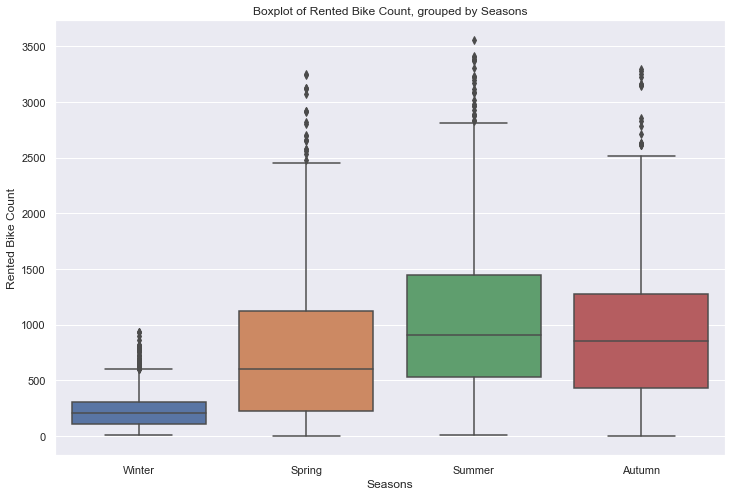

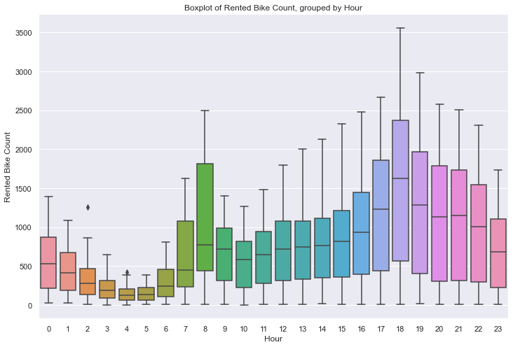

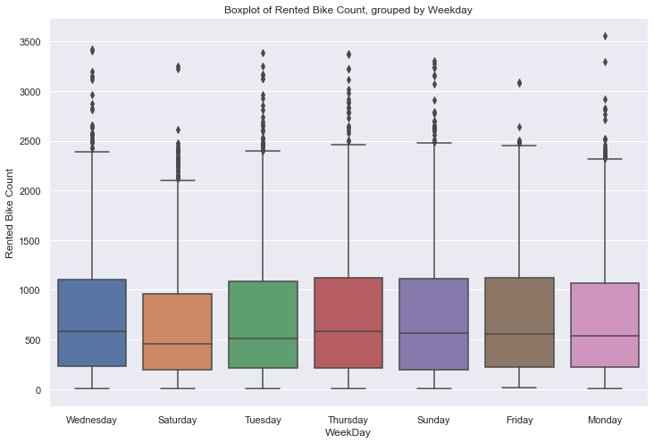

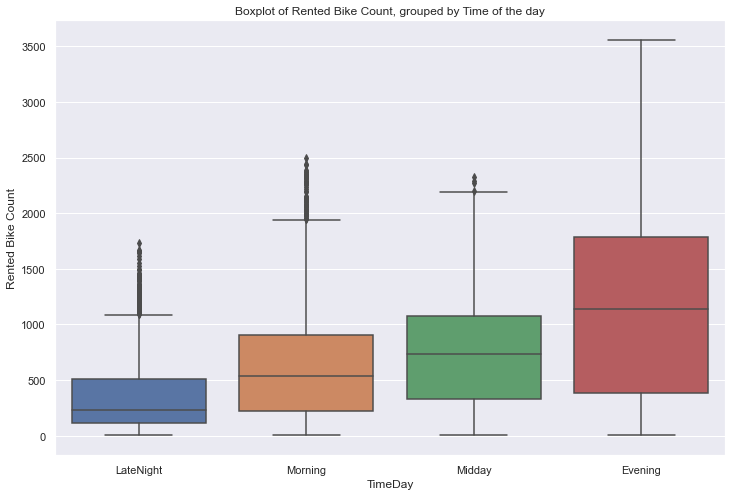

```python
sns.boxplot(x=bike["Seasons"], y=bike["Rented Bike Count"])
plt.title("Boxplot of Rented Bike Count, grouped by Seasons")
plt.show()

sns.boxplot(x=bike["Hour"], y=bike["Rented Bike Count"])
plt.title("Boxplot of Rented Bike Count, grouped by Hour")
plt.show()

sns.boxplot(x=bike["WeekDay"], y=bike["Rented Bike Count"])
plt.title("Boxplot of Rented Bike Count, grouped by Weekday")
plt.show()

sns.boxplot(x=bike["TimeDay"], y=bike["Rented Bike Count"])
plt.title("Boxplot of Rented Bike Count, grouped by Time of the day")
plt.show()
```

**Rented Bike by Holiday**

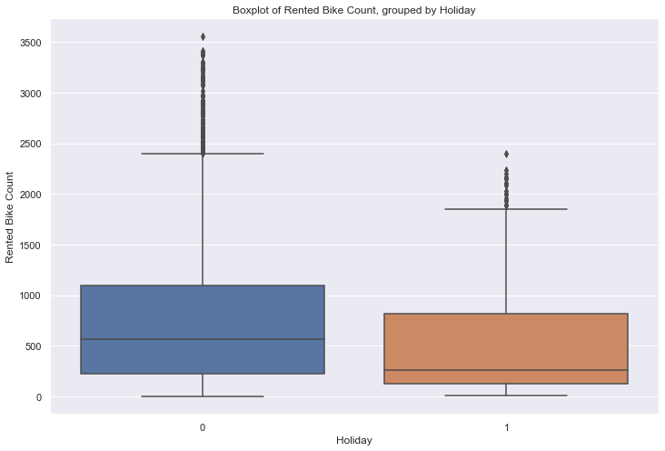

```python
sns.boxplot(x=bike["Holiday"], y=bike["Rented Bike Count"])
plt.title("Boxplot of Rented Bike Count, grouped by Holiday")
plt.show()
```

**Weather Conditions (Humidity and Temperature) vs Rented Bikes**

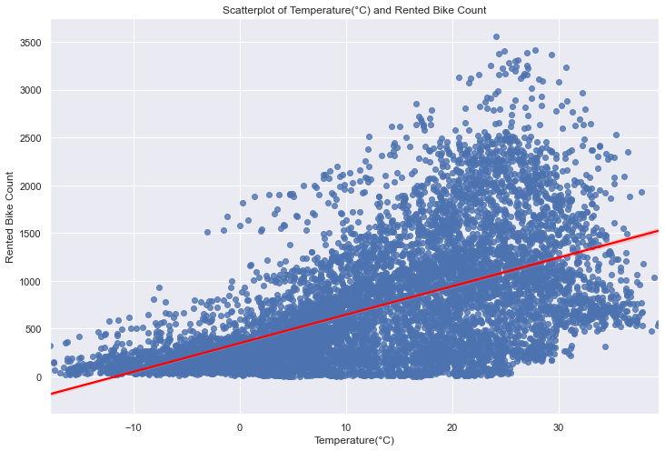

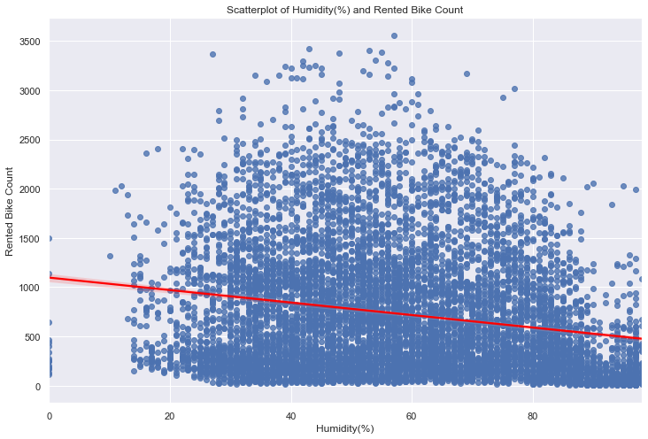

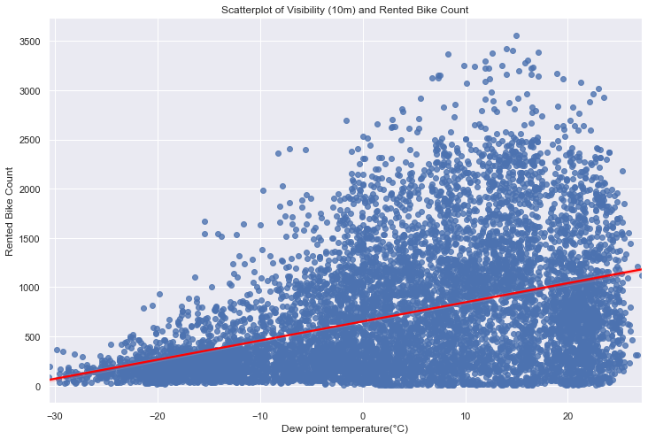

```python
sns.regplot(x=bike['Temperature(°C)'], y=bike['Rented Bike Count'], line_kws={"color": "red"}).set_title("Scatterplot of Temperature(°C) and Rented Bike Count")
plt.show()

sns.regplot(x=bike['Humidity(%)'], y=bike['Rented Bike Count'], line_kws={"color": "red"}).set_title("Scatterplot of Humidity(%) and Rented Bike Count")
plt.show()

sns.regplot(x=bike['Dew point temperature(°C)'], y=bike['Rented Bike Count'], line_kws={"color": "red"}).set_title("Scatterplot of Visibility (10m) and Rented Bike Count")
plt.show()
```

**Weather Conditions (Miscellaneous) vs Rented Bikes**

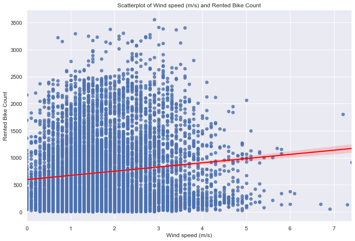

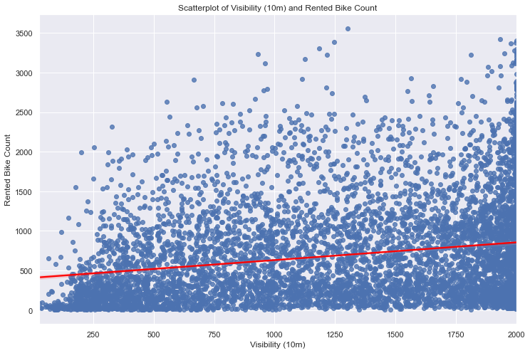

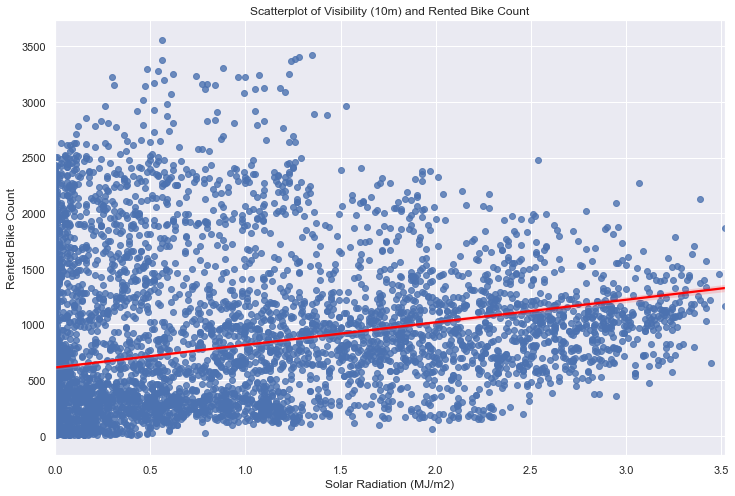

```python
sns.regplot(x=bike['Wind speed (m/s)'], y=bike['Rented Bike Count'], line_kws={"color": "red"}).set_title("Scatterplot of Wind speed (m/s) and Rented Bike Count")
plt.show()

sns.regplot(x=bike['Visibility (10m)'], y=bike['Rented Bike Count'], line_kws={"color": "red"}).set_title("Scatterplot of Visibility (10m) and Rented Bike Count")
plt.show()

sns.regplot(x=bike['Solar Radiation (MJ/m2)'], y=bike['Rented Bike Count'], line_kws={"color": "red"}).set_title("Scatterplot of Visibility (10m) and Rented Bike Count")
plt.show()
```

**Weather conditions correlation with Rented Bikes Count**

```python
coef, p_val = stats.pearsonr(bike['Temperature(°C)'], bike['Rented Bike Count'])
print('Correlation Between Rented Bike Count and Temperature, Coeff: {:.4f}, p value: {:.4f}'.format(coef, p_val))

coef, p_val = stats.pearsonr(bike['Humidity(%)'], bike['Rented Bike Count'])
print('\nCorrelation Between Rented Bike Count and Humidity(%), Coeff: {:.4f}, p value: {:.4f}'.format(coef, p_val))

coef, p_val = stats.pearsonr(bike['Wind speed (m/s)'], bike['Rented Bike Count'])
print('\nCorrelation Between Rented Bike Count and Wind speed (m/s), Coeff: {:.4f}, p value: {:.4f}'.format(coef, p_val))

coef, p_val = stats.pearsonr(bike['Visibility (10m)'], bike['Rented Bike Count'])
print('\nCorrelation Between Rented Bike Count and Visibility (10m), Coeff: {:.4f}, p value: {:.4f}'.format(coef, p_val))

coef, p_val = stats.pearsonr(bike['Dew point temperature(°C)'], bike['Rented Bike Count'])
print('\nCorrelation Between Rented Bike Count and Dew point temperature(°C), Coeff: {:.4f}, p value: {:.4f}'.format(coef, p_val))

coef, p_val = stats.pearsonr(bike['Solar Radiation (MJ/m2)'], bike['Rented Bike Count'])
print('\nCorrelation Between Rented Bike Count and Solar Radiation (MJ/m2), Coeff: {:.4f}, p value: {:.4f}'.format(coef, p_val))
```

```
Correlation Between Rented Bike Count and Temperature, Coeff: 0.5627, p value: 0.0000

Correlation Between Rented Bike Count and Humidity(%), Coeff: -0.2020, p value: 0.0000

Correlation Between Rented Bike Count and Wind speed (m/s), Coeff: 0.1250, p value: 0.0000

Correlation Between Rented Bike Count and Visibility (10m), Coeff: 0.2123, p value: 0.0000

Correlation Between Rented Bike Count and Dew point temperature(°C), Coeff: 0.4003, p value: 0.0000

Correlation Between Rented Bike Count and Solar Radiation (MJ/m2), Coeff: 0.2739, p value: 0.0000
```

**Precipitation vs Rented Bikes**

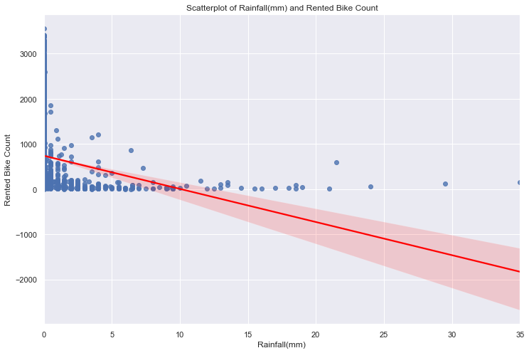

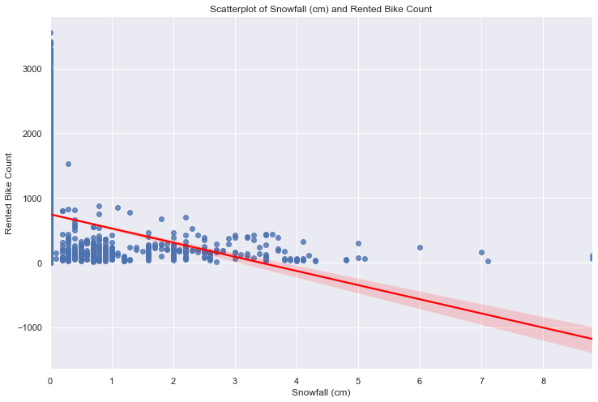

```python
sns.regplot(x=bike['Rainfall(mm)'], y=bike['Rented Bike Count'], line_kws={"color": "red"}).set_title("Scatterplot of Rainfall(mm) and Rented Bike Count")
plt.show()

sns.regplot(x=bike['Snowfall (cm)'], y=bike['Rented Bike Count'], line_kws={"color": "red"}).set_title("Scatterplot of Snowfall (cm) and Rented Bike Count")
plt.show()
```

**Precipitation (binary) vs Rented Bikes**

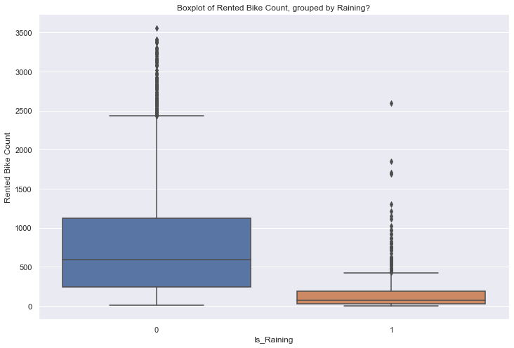

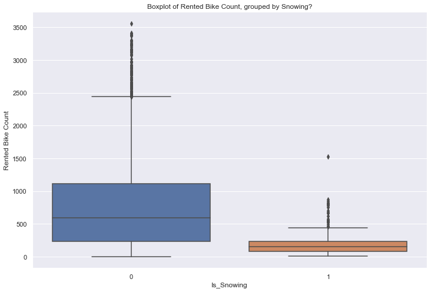

```python
sns.boxplot(x=bike["Is_Raining"], y=bike["Rented Bike Count"])
plt.title("Boxplot of Rented Bike Count, grouped by Raining?")
plt.show()

sns.boxplot(x=bike["Is_Snowing"], y=bike["Rented Bike Count"])
plt.title("Boxplot of Rented Bike Count, grouped by Snowing?")
plt.show()
```

**Precipitation correlation with Rented Bike Count**

```python
coef, p_val = stats.pearsonr(bike['Rainfall(mm)'], bike['Rented Bike Count'])
print('Correlation Between Rented Bike Count and Rainfall(mm), Coeff: {:.4f}, p value: {:.4f}'.format(coef, p_val))

coef, p_val = stats.pearsonr(bike['Snowfall (cm)'], bike['Rented Bike Count'])
print('\nCorrelation Between Rented Bike Count and Snowfall (cm), Coeff: {:.4f}, p value: {:.4f}'.format(coef, p_val))
```

```
Correlation Between Rented Bike Count and Rainfall(mm), Coeff: -0.1286, p value: 0.0000

Correlation Between Rented Bike Count and Snowfall (cm), Coeff: -0.1516, p value: 0.0000
```

**Correlation between Dew Point Temperature and Ambient Temperature**

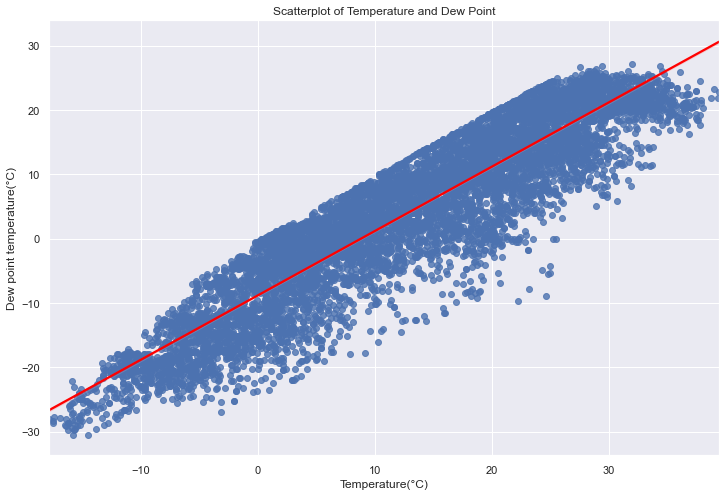

```
Correlation Between Temperature and Dew Point, Coeff: 0.9145, p value: 0.0000
```

```python
sns.regplot(x=bike['Temperature(°C)'], y=bike['Dew point temperature(°C)'], line_kws={"color": "red"}).set_title("Scatterplot of Temperature and Dew Point")
plt.show()

coef, p_val = stats.pearsonr(bike['Temperature(°C)'], bike['Dew point temperature(°C)'])
print('Correlation Between Temperature and Dew Point, Coeff: {:.4f}, p value: {:.4f}'.format(coef, p_val))
```

## Variables to drop

`Visibility (10m)`: Apparent low correlation `Dew point temperature(°C)`: Strongly correlated to `Temperature(°C)`. Favoured `Temperature(°C)` varaible over it. `Solar Radiation (MJ/m2)`: Apparent low correlation `Wind speed (m/s)`: Apparent low correlation

**VIF Analysis**

```python
from statsmodels.stats.outliers_influence import variance_inflation_factor
# Set up X and Y
X_columns = ['Temperature(°C)','Humidity(%)','Rainfall(mm)','Snowfall (cm)','Summer','Winter','Spring', 'Holiday',1,2,3,4,5,6,7,8,9,10,11,12,13,14,15,16,17,18,19,20,21,22,23]
X = bike[X_columns]
Y = bike['Rented Bike Count']
X = sm.add_constant(X)

# Calculate VIF
vif = pd.DataFrame()
vif["VIF Factor"] = [variance_inflation_factor(X.values, i) for i in range(X.shape[1])]
vif["features"] = X.columns

# Inspect VIF Values, round it to 2 decimal places
vif.round(2)
```

|  | VIF Factor | features |
| --- | --- | --- |
| 0 | 46.44 | const |
| 1 | 4.99 | Temperature(°C) |
| 2 | 1.55 | Humidity(%) |
| 3 | 1.09 | Rainfall(mm) |
| 4 | 1.11 | Snowfall (cm) |
| 5 | 2.66 | Summer |
| 6 | 3.34 | Winter |
| 7 | 1.59 | Spring |
| 8 | 1.02 | Holiday |
| 9 | 1.92 | 1 |
| 10 | 1.92 | 2 |
| 11 | 1.92 | 3 |
| 12 | 1.92 | 4 |
| 13 | 1.92 | 5 |
| 14 | 1.92 | 6 |
| 15 | 1.93 | 7 |
| 16 | 1.92 | 8 |
| 17 | 1.93 | 9 |
| 18 | 1.94 | 10 |
| 19 | 1.97 | 11 |
| 20 | 2.00 | 12 |
| 21 | 2.02 | 13 |
| 22 | 2.03 | 14 |
| 23 | 2.04 | 15 |
| 24 | 2.03 | 16 |
| 25 | 2.00 | 17 |
| 26 | 1.98 | 18 |
| 27 | 1.95 | 19 |
| 28 | 1.94 | 20 |
| 29 | 1.93 | 21 |
| 30 | 1.92 | 22 |
| 31 | 1.92 | 23 |

**Regression Model**

```python
X_columns = ['Temperature(°C)','Rainfall(mm)','Snowfall (cm)','Summer','Winter','Spring', 'Holiday',1,2,3,4,5,6,7,8,9,10,11,12,13,14,15,16,17,18,19,20,21,22,23]
X = bike[X_columns]
Y = bike['Rented Bike Count']
X = sm.add_constant(X)
model2 = sm.OLS(Y, X).fit()
print(model2.summary())
```

```
                            OLS Regression Results
==============================================================================
Dep. Variable:      Rented Bike Count   R-squared:                       0.620
Model:                            OLS   Adj. R-squared:                  0.619
Method:                 Least Squares   F-statistic:                     458.6
Date:                Fri, 13 Nov 2020   Prob (F-statistic):               0.00
Time:                        14:38:22   Log-Likelihood:                -62643.
No. Observations:                8465   AIC:                         1.253e+05
Df Residuals:                    8434   BIC:                         1.256e+05
Df Model:                          30
Covariance Type:            nonrobust
===================================================================================
                      coef    std err          t      P>|t|      [0.025      0.975]
-----------------------------------------------------------------------------------
const             488.5000     24.572     19.880      0.000     440.332     536.668
Temperature(°C)    22.9691      0.792     29.010      0.000      21.417      24.521
Rainfall(mm)      -96.1040      3.850    -24.959      0.000    -103.652     -88.556
Snowfall (cm)     -30.0700     10.035     -2.996      0.003     -49.742     -10.398
Summer           -173.6773     15.999    -10.856      0.000    -205.039    -142.316
Winter           -319.7467     18.005    -17.759      0.000    -355.041    -284.453
Spring           -155.1481     12.455    -12.457      0.000    -179.562    -130.734
Holiday          -108.6099     20.371     -5.332      0.000    -148.542     -68.678
1                -114.2619     29.904     -3.821      0.000    -172.880     -55.644
2                -232.4753     29.907     -7.773      0.000    -291.100    -173.851
3                -322.9591     29.912    -10.797      0.000    -381.595    -264.324
4                -389.4691     29.918    -13.018      0.000    -448.117    -330.821
5                -384.8214     29.925    -12.859      0.000    -443.483    -326.160
6                -218.9294     29.933     -7.314      0.000    -277.605    -160.254
7                 108.3821     29.911      3.624      0.000      49.750     167.014
8                 520.8340     29.895     17.422      0.000     462.232     579.436
9                 123.5212     29.894      4.132      0.000      64.921     182.122
10                -47.7561     29.917     -1.596      0.110    -106.400      10.888
11                 -1.2803     29.986     -0.043      0.966     -60.060      57.500
12                 75.4693     30.071      2.510      0.012      16.522     134.416
13                 96.1594     30.148      3.190      0.001      37.062     155.256
14                 93.4536     30.201      3.094      0.002      34.253     152.654
15                166.5969     30.226      5.512      0.000     107.346     225.848
16                266.8455     30.208      8.834      0.000     207.631     326.060
17                502.9557     30.139     16.688      0.000     443.876     562.035
18                915.9450     30.059     30.471      0.000     857.021     974.869
19                606.0023     29.976     20.216      0.000     547.242     664.763
20                510.2418     29.935     17.045      0.000     451.561     568.923
21                485.4715     29.910     16.231      0.000     426.840     544.103
22                369.1542     29.890     12.350      0.000     310.563     427.746
23                120.3063     29.883      4.026      0.000      61.728     178.884
==============================================================================
Omnibus:                      311.049   Durbin-Watson:                   0.344
Prob(Omnibus):                  0.000   Jarque-Bera (JB):              730.566
Skew:                           0.204   Prob(JB):                    2.29e-159
Kurtosis:                       4.380   Cond. No.                         432.
==============================================================================

Warnings:
[1] Standard Errors assume that the covariance matrix of the errors is correctly specified.
```

**Partial Regression Plots for all Predictors**

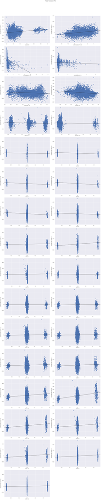

```python
fig = plt.figure(figsize=(20,100))
fig = sm.graphics.plot_partregress_grid(model2, fig=fig)
plt.show()
```

**Distribution of the Residuals around 0**

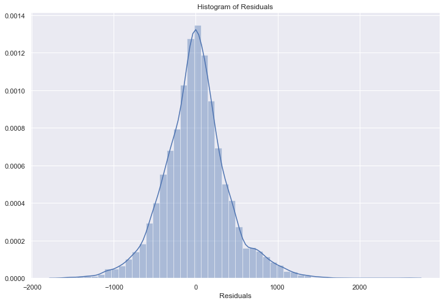

```python
sns.distplot(model2.resid)
plt.xlabel('Residuals')
plt.title('Histogram of Residuals')
plt.show()
```

**Residuals vs. Predicted Values**

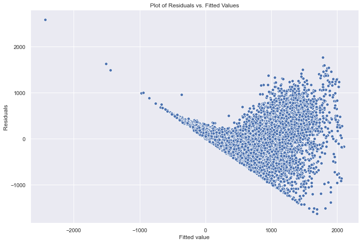

```python
sns.scatterplot(model2.fittedvalues, model2.resid)
plt.title('Plot of Residuals vs. Fitted Values')
plt.xlabel('Fitted value')
plt.ylabel('Residuals')
plt.show()
```

**Cook's Distance**

```python
influence = model2.get_influence()
# show the influence analysis summary
print(influence.summary_table())
```

```
==================================================================================================
       obs      endog     fitted     Cook's   student.   hat diag    dffits   ext.stud.     dffits
                           value          d   residual              internal   residual
--------------------------------------------------------------------------------------------------
         0    254.000     49.314      0.000      0.517      0.003      0.030      0.517      0.029
         1    204.000    -71.839      0.000      0.696      0.003      0.040      0.696      0.040
         2    173.000   -201.536      0.000      0.946      0.003      0.054      0.946      0.054
         3    107.000   -296.614      0.000      1.019      0.003      0.058      1.019      0.058
         4     78.000   -358.530      0.000      1.102      0.003      0.063      1.102      0.063
         5    100.000   -363.070      0.000      1.169      0.003      0.067      1.169      0.067
         6    181.000   -201.772      0.000      0.966      0.003      0.055      0.966      0.055
         7    460.000    107.164      0.000      0.891      0.003      0.051      0.891      0.051
         8    930.000    515.022      0.000      1.048      0.003      0.060      1.048      0.060
         9    490.000    142.975      0.000      0.876      0.003      0.050      0.876      0.050
        10    339.000     40.605      0.000      0.753      0.003      0.043      0.753      0.043
```

[output cut: 8455 more lines]

**Cook's Distance (Visual)**

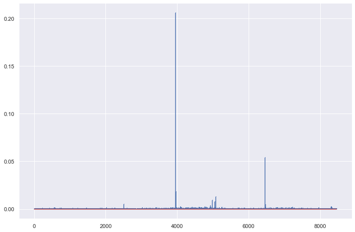

```python
(c, p) = influence.cooks_distance
plt.stem(np.arange(len(c)), c, markerfmt=",", use_line_collection=True)
plt.show()
```